# Willy Chen

# **This page is no longer maintained timely. For latest updates, visit willy.netlify.app**

[figure not shown]

Welcome to my personal website. You can find my biography and my work here.

You can find my revised board game **The Democratic Republicans** in the *About Me* section.

You can find videos, slides, and lecture notes of my R workshop under coding examples.

## About Me

I am currently an MA’20 candidate of Economics at the University of Chicago. I obtained my B.S. in both Economics and Mathematics from The Ohio State University in Spring 2019.

My research interest is in public economics with current focus on the migration effect of Sanctuary City Policies.

I am a self-proclaimed magician, photographer, boardgame-maker, and funny T-shirt enthusiast.

Check out my newest revision of the game secret hitler called **[The Deomocratic Republicans](https://willythewoo.github.io/WillyTheWoo/The_Democratic_Republicans.pdf)**

## Photography

Click on the picture to see the whole album

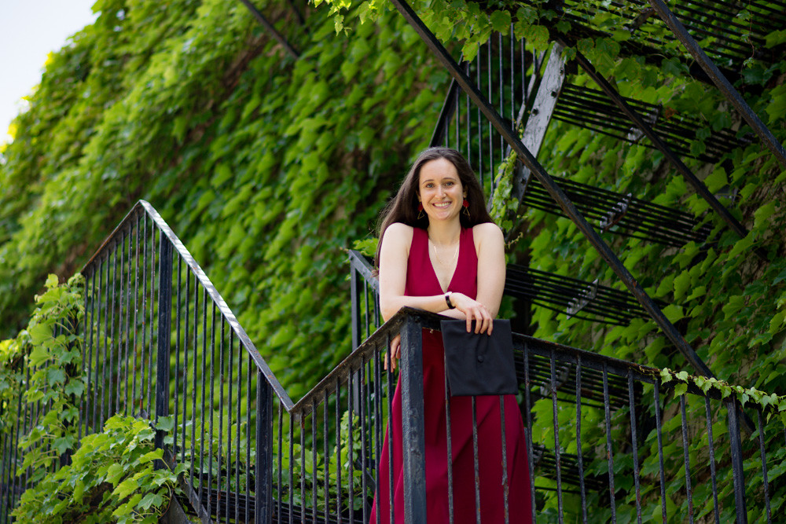

## Curriculum Vitae

Last Updated: 2020-07-13 [Link](https://willythewoo.github.io/WillyTheWoo/cvWillyChen.pdf)

[interactive chart not shown]

## Coding Projects/Examples

### Projects

**[Latest Update: Principles of data visualization workshop](https://willythewoo.github.io/WillyTheWoo/workshop/menu.html)**

[Corona Virus Resources](https://willychen.shinyapps.io/covid-resources/)

[University Ambassador Scheduling System](https://willythewoo.github.io/WillyTheWoo/coding/Ambassador_Schedule)

### Codes

[Taiwanese Housing Auction (Web scraping / Geocoding)](https://willythewoo.github.io/WillyTheWoo/coding/Taiwan_housing)

[Twitter scraping and sentiment analysis](https://willythewoo.github.io/WillyTheWoo/coding/twitter)

[Single-Player Battleship in R](https://willythewoo.github.io/WillyTheWoo/coding/Battleship)

## Contact Information

Academic Email: willyc@uchicago.edu

Personal Email: wchen6149@gmail.com